# Lecture 2 — Intermediate/Advanced BigQuery for GA4

IBM 6500 | Google Merchandise Store sample

Spencer Conway

November 12, 2026

This notebook uses the GA4 ecommerce sample to practice working with nested data, combining daily summaries, and calculating rankings and moving averages. Each example states what one row in its output represents.

The screenshots show the BigQuery results. For longer tables, they show the rows and columns visible in the results pane.

# 1. CTEs with WITH

## 01. Total users and new users

```sql
WITH UserInfo AS (
  SELECT
    user_pseudo_id,
    MAX(IF(event_name IN ('first_visit', 'first_open'), 1, 0)) AS is_new_user
  FROM `bigquery-public-data.ga4_obfuscated_sample_ecommerce.events_*`
  WHERE _TABLE_SUFFIX BETWEEN '20201101' AND '20201130'
    AND user_pseudo_id IS NOT NULL
  GROUP BY user_pseudo_id
)
SELECT
  COUNT(*) AS total_users,
  COALESCE(SUM(is_new_user), 0) AS new_users
FROM UserInfo;
```

I used the CTE to make one row per identified user for November. The flag is 1 if the user had at least one `first_visit` or `first_open` event. The final row gives the total number of users and how many had that flag.

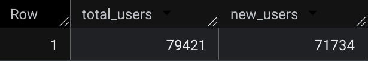

BigQuery results for query 01

The query returned 79,421 identified users in November. Of those, 71,734 were flagged as new.

# 2. Arrays and UNNEST

## 02. Pull the page URL from event parameters

```sql
SELECT
  TIMESTAMP_MICROS(event_timestamp) AS event_time,
  (
    SELECT value.string_value
    FROM UNNEST(event_params)
    WHERE key = 'page_location'
    LIMIT 1
  ) AS page_location
FROM `bigquery-public-data.ga4_obfuscated_sample_ecommerce.events_*`
WHERE event_name = 'page_view'
  AND _TABLE_SUFFIX BETWEEN '20201201' AND '20201202'
LIMIT 50;
```

Each page view has an array of parameters. This query looks for `page_location` inside the array and converts the event timestamp from microseconds. It keeps one row per page view, even if the URL is missing. The 50 rows are an unsorted preview.

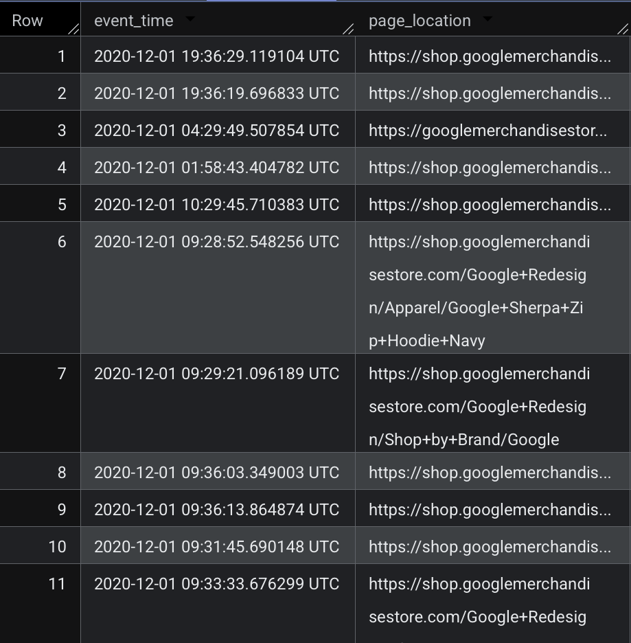

BigQuery results for query 02

The output shows the UTC timestamp next to each page URL. One visible row points to the Google Sherpa Zip Hoodie Navy product page.

## 03. Count item rows in purchase events

```sql
SELECT
  e.event_date,
  item.item_name,
  COUNT(*) AS item_rows
FROM `bigquery-public-data.ga4_obfuscated_sample_ecommerce.events_*` AS e
CROSS JOIN UNNEST(e.items) AS item
WHERE e.event_name = 'purchase'
  AND _TABLE_SUFFIX BETWEEN '20201201' AND '20201231'
GROUP BY e.event_date, item.item_name
ORDER BY item_rows DESC, e.event_date, item.item_name
LIMIT 20;
```

Here I unnested `items` in the `FROM` clause. A purchase with three item entries contributes three rows. The result shows the 20 highest day-and-item counts. To count units sold, I would add up item quantities instead of counting rows.

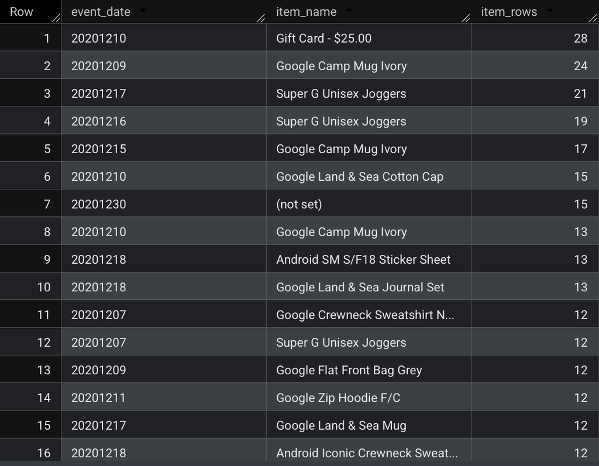

BigQuery results for query 03

The $25 gift card had the highest count in the results, with 28 item rows on December 10.

# 3. STRING_AGG and ARRAY_AGG

## 04. List the event types seen each day

```sql
SELECT
  event_date,
  STRING_AGG(DISTINCT event_name, ', ' ORDER BY event_name) AS events_seen
FROM `bigquery-public-data.ga4_obfuscated_sample_ecommerce.events_*`
WHERE _TABLE_SUFFIX BETWEEN '20201201' AND '20201203'
GROUP BY event_date
ORDER BY event_date;
```

I used `STRING_AGG` to put the unique event names into one alphabetized text list per day. This gives me a quick way to see which kinds of events appeared from December 1 through 3.

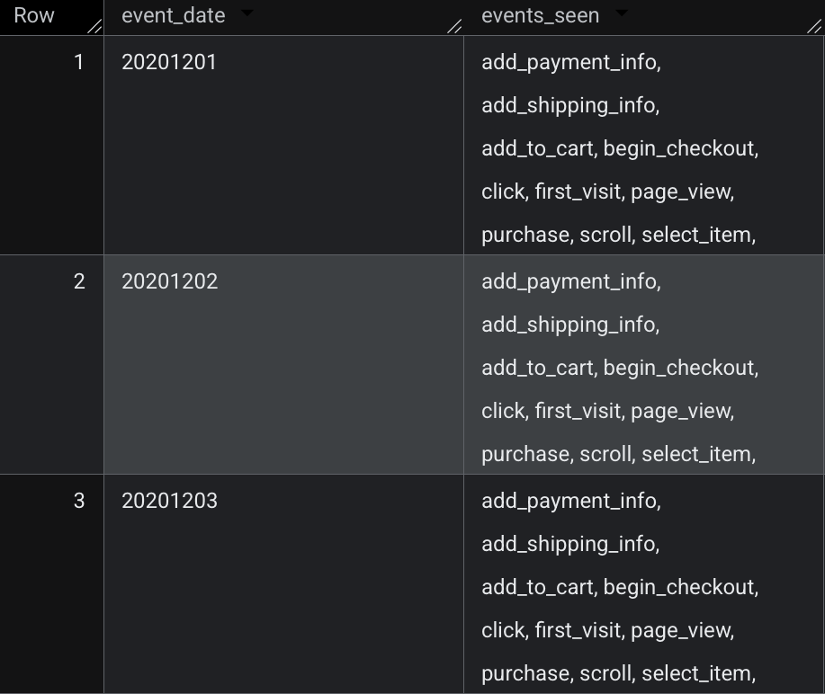

BigQuery results for query 04

The query returned three rows, one for each date. The visible lists all include events like page_view, add_to_cart, and purchase.

## 05. Collect cart item names by user

```sql
SELECT
  e.user_pseudo_id,
  ARRAY_AGG(item.item_name IGNORE NULLS ORDER BY e.event_timestamp, item.item_name)
    AS items_added_to_cart
FROM `bigquery-public-data.ga4_obfuscated_sample_ecommerce.events_*` AS e
CROSS JOIN UNNEST(e.items) AS item
WHERE e.event_name = 'add_to_cart'
  AND _TABLE_SUFFIX BETWEEN '20201201' AND '20201231'
  AND e.user_pseudo_id IS NOT NULL
GROUP BY e.user_pseudo_id
ORDER BY e.user_pseudo_id
LIMIT 10;
```

This example groups by `user_pseudo_id`, so each row can include items from several sessions in December. Repeated item names stay in the array. The query returns a preview of 10 users.

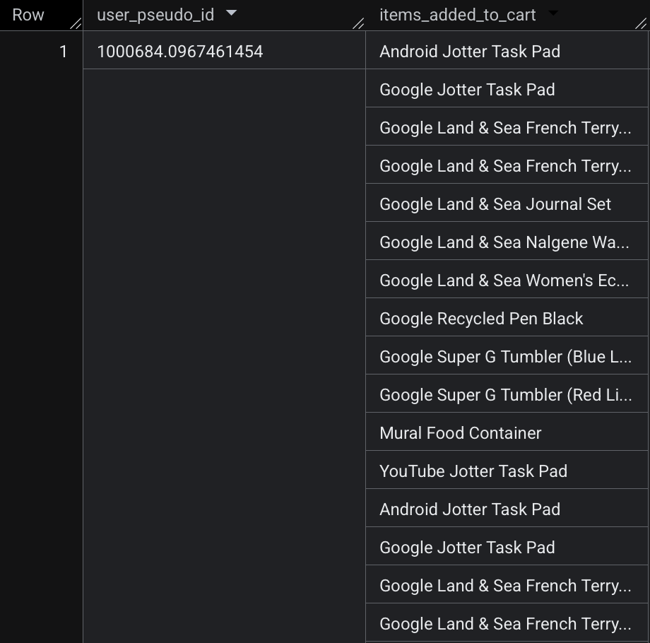

BigQuery results for query 05

The first user’s list includes the Android Jotter Task Pad more than once. The array keeps repeated names, so I can see that the same item shows up in multiple entries.

## 06. Build a cart summary by session

```sql
WITH add_to_cart AS (
  SELECT
    e.user_pseudo_id,
    (
      SELECT value.int_value
      FROM UNNEST(e.event_params)
      WHERE key = 'ga_session_id'
      LIMIT 1
    ) AS session_id,
    TIMESTAMP_MICROS(e.event_timestamp) AS event_time,
    item.item_id,
    item.item_name,
    item.quantity,
    item.price
  FROM `bigquery-public-data.ga4_obfuscated_sample_ecommerce.events_*` AS e
  CROSS JOIN UNNEST(e.items) AS item
  WHERE e.event_name = 'add_to_cart'
    AND _TABLE_SUFFIX BETWEEN '20210101' AND '20210131'
    AND e.user_pseudo_id IS NOT NULL
)
SELECT
  user_pseudo_id,
  session_id,
  COUNT(*) AS total_cart_item_rows,
  ARRAY_AGG(
    STRUCT(item_id, item_name, quantity, price, event_time)
    ORDER BY quantity DESC, event_time, item_id, item_name, price
    LIMIT 10
  ) AS cart_items
FROM add_to_cart
WHERE session_id IS NOT NULL
GROUP BY user_pseudo_id, session_id
ORDER BY user_pseudo_id, session_id;
```

I pulled `ga_session_id` from the event parameters and paired it with the user ID. Each row counts the item entries added during that session and shows up to 10 of them, ordered by quantity and then time. The count is based on item entries after `UNNEST`. January 2021 is the last month available in this sample.

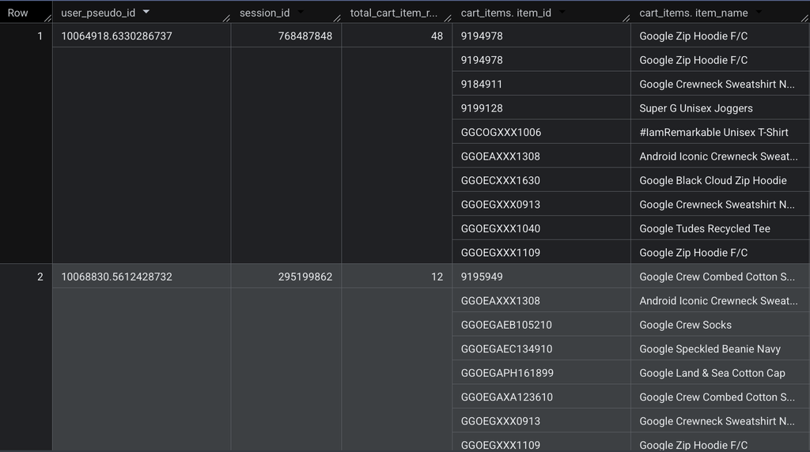

BigQuery results for query 06

The first session had 48 cart item rows, and the array displayed 10 of those entries.

# 4. Joins

## 07. Join daily users with daily purchases

```sql
WITH daily_users AS (
  SELECT
    event_date,
    COUNT(DISTINCT user_pseudo_id) AS users
  FROM `bigquery-public-data.ga4_obfuscated_sample_ecommerce.events_*`
  WHERE _TABLE_SUFFIX BETWEEN '20201201' AND '20201231'
  GROUP BY event_date
),
daily_purchases AS (
  SELECT
    event_date,
    COUNT(DISTINCT NULLIF(ecommerce.transaction_id, '')) AS purchases
  FROM `bigquery-public-data.ga4_obfuscated_sample_ecommerce.events_*`
  WHERE event_name = 'purchase'
    AND _TABLE_SUFFIX BETWEEN '20201201' AND '20201231'
  GROUP BY event_date
)
SELECT
  u.event_date,
  u.users,
  COALESCE(p.purchases, 0) AS purchases,
  ROUND(SAFE_DIVIDE(COALESCE(p.purchases, 0), u.users) * 100, 2)
    AS transactions_per_100_users
FROM daily_users AS u
LEFT JOIN daily_purchases AS p
  ON u.event_date = p.event_date
ORDER BY u.event_date;
```

The first CTE counts users each day, and the second counts distinct transaction IDs from purchase events. A `LEFT JOIN` keeps days from the users table even when there is no matching purchase row. The last column gives transactions per 100 users. A single user can place multiple orders, so measuring buyer conversion would require counting distinct users who purchased.

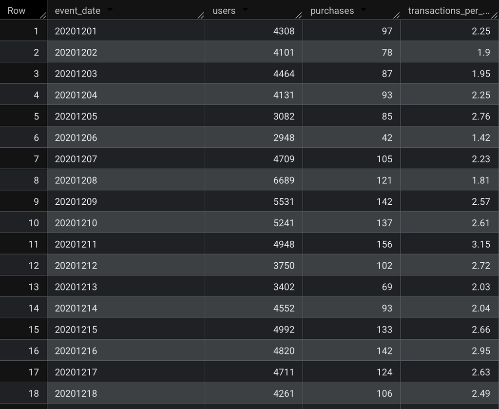

BigQuery results for query 07

On December 1, the query counted 97 distinct transactions and 4,308 users. That comes out to 2.25 transactions per 100 users.

# 5. Window functions and QUALIFY

## 08. Find the top three event ranks each day

```sql
WITH daily_event_counts AS (
  SELECT
    event_date,
    event_name,
    COUNT(*) AS events
  FROM `bigquery-public-data.ga4_obfuscated_sample_ecommerce.events_*`
  WHERE _TABLE_SUFFIX BETWEEN '20201201' AND '20201207'
  GROUP BY event_date, event_name
)
SELECT
  event_date,
  event_name,
  events,
  RANK() OVER (PARTITION BY event_date ORDER BY events DESC) AS rnk
FROM daily_event_counts
QUALIFY rnk <= 3
ORDER BY event_date, rnk, event_name;
```

I counted events by date and event name, then used `RANK()` to start a fresh ranking for each day. `QUALIFY` keeps the rows ranked third or higher. A tie at the cutoff can give a day more than three rows.

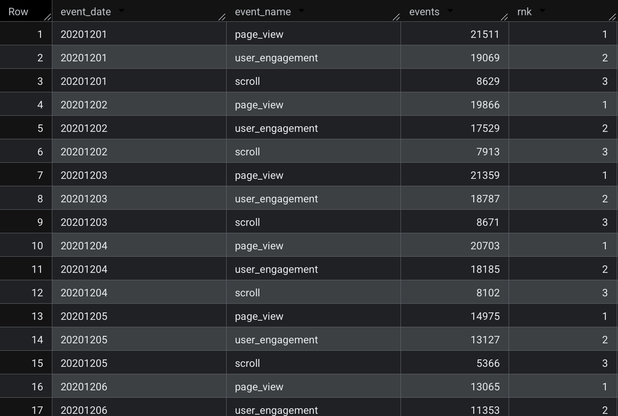

BigQuery results for query 08

On December 1, page_view ranked first with 21,511 events, followed by user_engagement and scroll.

## 09. Calculate a rolling seven-day purchase average

```sql
WITH calendar AS (
  SELECT dt
  FROM UNNEST(GENERATE_DATE_ARRAY(DATE '2020-12-01', DATE '2020-12-31')) AS dt
),
daily_purchases AS (
  SELECT
    PARSE_DATE('%Y%m%d', event_date) AS dt,
    COUNT(*) AS purchase_events
  FROM `bigquery-public-data.ga4_obfuscated_sample_ecommerce.events_*`
  WHERE event_name = 'purchase'
    AND _TABLE_SUFFIX BETWEEN '20201201' AND '20201231'
  GROUP BY dt
)
SELECT
  calendar.dt,
  COALESCE(daily_purchases.purchase_events, 0) AS purchase_events,
  AVG(COALESCE(daily_purchases.purchase_events, 0)) OVER (
    ORDER BY calendar.dt
    ROWS BETWEEN 6 PRECEDING AND CURRENT ROW
  ) AS purchases_7d_avg
FROM calendar
LEFT JOIN daily_purchases USING (dt)
ORDER BY calendar.dt;
```

This query counts purchase event rows per day and fills in any December dates with zero purchases. The window averages the current day and the six previous days when available. December 1 through 6 use the days available so far in the month.

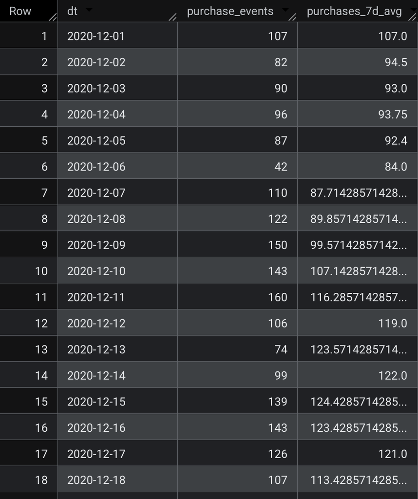

BigQuery results for query 09

December 7 had 110 purchase events, but the average for December 1–7 was about 87.7 per day. The rolling average smooths out daily swings like this.

# 6. Approximate functions

## 10. Estimate distinct users per event type

```sql
SELECT
  event_name,
  APPROX_COUNT_DISTINCT(user_pseudo_id) AS approx_users
FROM `bigquery-public-data.ga4_obfuscated_sample_ecommerce.events_*`
WHERE _TABLE_SUFFIX BETWEEN '20201201' AND '20201231'
GROUP BY event_name
ORDER BY approx_users DESC, event_name
LIMIT 15;
```

I used `APPROX_COUNT_DISTINCT` to estimate how many different users triggered each event in December. The output shows the 15 event types with the highest estimates. I would use `COUNT(DISTINCT ...)` if I needed exact counts.

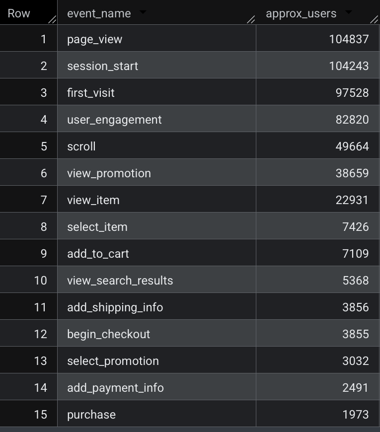

BigQuery results for query 10

Page views had the highest estimate at 104,837 users. About 7,109 users triggered add_to_cart and 1,973 triggered purchase.

# Appendix

- [GitHub repository](https://github.com/Spencerconway0/ibm-6500-sql-learning-portfolio)
- [Lecture 2 report on GitHub Pages](https://spencerconway0.github.io/ibm-6500-sql-learning-portfolio/lecture2-ga4.html)
- [GA4 ecommerce sample dataset](https://developers.google.com/analytics/bigquery/web-ecommerce-demo-dataset)
- [GA4 BigQuery export schema](https://support.google.com/analytics/answer/7029846)